# CausalFeatureEngineering

Uli Kaulfuss

17 Januar 2020

# Objective

The purpose of this analysis is to understand and quantify the different drivers that contribute to good wellbeing (good / very good = GZmehm1) in order to give individual advice to improve peoples’ lives.

The response variable GZmehm1 is a rating of individual wellbeing on a 5-step scale 1= very bad | 5=very good.

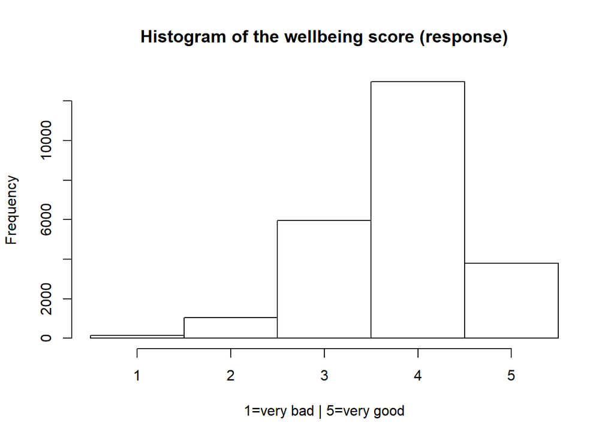

# Feature engineering:

Combining features for causal analysis in accordance with the survey

#### Initially we want to set a baseline analysis of overall drivers for wellbeing crossing the entire population in Germany

Ensure that the correct encoding (factor, numeric, …) is applied according to the meta data from base dataset before for further feature enginering

## Feature engineering

Combine a new feature “how many portions do you eat vegies/fruit per day in a week?” People that have 4 to 6 portions of fruit per week have (coded = 2) on average 5 portions per week => 5 portions / 7 days in a week

```r
df_overall[df_overall$ENobstB == 2 & !is.na(df_overall$ENobstBz1),]$ENobstBz1 = round(5/7,2)
df_overall[df_overall$ENobstB == 3 & !is.na(df_overall$ENobstBz1),]$ENobstBz1 = round(2/7,2)
df_overall[df_overall$ENobstB == 4 & !is.na(df_overall$ENobstBz1),]$ENobstBz1 = round(1/7,2)
df_overall[df_overall$ENobstB == 5 & !is.na(df_overall$ENobstBz1),]$ENobstBz1 = 0

df_overall$ENobstBz1 <- as.numeric(df_overall$ENobstBz1)

# deselect the question
df_overall<- df_overall %>% dplyr::select(-ENobstB)
```

Do the same with veggies. people that have 4 to 6 portions of vegies per week have (coded = 2) on average 5 portions per week => 5 portions / 7 days in a week

```r
df_overall[df_overall$ENgemB == 2 & !is.na(df_overall$ENgemBz1),]$ENgemBz1 = round(5/7,2)
df_overall[df_overall$ENgemB == 3 & !is.na(df_overall$ENgemBz1),]$ENgemBz1 = round(2/7,2)
df_overall[df_overall$ENgemB == 4 & !is.na(df_overall$ENgemBz1),]$ENgemBz1 = round(1/7,2)
df_overall[df_overall$ENgemB == 5 & !is.na(df_overall$ENgemBz1),]$ENgemBz1 = 0

df_overall$ENgemBz1 <- as.numeric(df_overall$ENgemBz1)

# deselect the question
df_overall<- df_overall %>% dplyr::select(-ENgemB)
```

Aggregate types of schools within German school system

```r
df_overall[(df_overall$SDbild1D == 8 | df_overall$SDbild1D == 1 | df_overall$SDbild1D == 2 | df_overall$SDbild1D == 3) & !is.na(df_overall$SDbild1D),]$SDbild1D <- 2
df_overall[(df_overall$SDbild1D == 3 | df_overall$SDbild1D == 4 | df_overall$SDbild1D == 5) & !is.na(df_overall$SDbild1D) ,]$SDbild1D <- 5
df_overall[(df_overall$SDbild1D == 6 | df_overall$SDbild1D == 7) & !is.na(df_overall$SDbild1D) ,]$SDbild1D <- 7

df_overall$SDbild1D <- drop.levels(df_overall$SDbild1D)
```

Encode minutes of sports during week as integer (1 unit == 30 minutes); -96 == no sport == 0 minutes

```r
df_overall[df_overall$KAspodauC_k == '-96' & !is.na(df_overall$KAspodauC_k),]$KAspodauC_k <- 0

df_overall$KAspodauC_k <- as.numeric(df_overall$KAspodauC_k)
```

Encode days mnissed due to sickness in numeric values (1 == 1 week == 7 days missed due to sickness)

```r
df_overall$AUarbzD_k <- as.numeric(df_overall$AUarbzD_k)
```

Set NA to values where people are not being asked about tetanus vaccinations

```r
df_overall[(df_overall$IPtet_lz == '-96' | df_overall$IPtet_lz == '-95' ) & !is.na(df_overall$IPtet_lz),]$IPtet_lz <- NA
```

Encode number of GP visited in the last 12 months –> if -96, then 0

```r
df_overall[df_overall$IAarzt1B4w == '-96' & !is.na(df_overall$IAarzt1B4w),]$IAarzt1B4w <- 0

df_overall$IAarzt1B4w <- as.numeric(df_overall$IAarzt1B4w)
```

Encode number of specialist visited in the last 12 months –> if -96, then 0

```r
df_overall[df_overall$IAfa4w == '-96' & !is.na(df_overall$IAfa4w),]$IAfa4w <- 0

df_overall$IAfa4w <- as.numeric(df_overall$IAfa4w)
```

Encode IAkhs_k as numeric where 1 unit == 7 days == 1 week spent in hospital

```r
df_overall$IAkhs_k <- as.numeric(df_overall$IAkhs_k)
```

Encode if the individual has had any injuries due to an accident in the past 12 months

```r
df_overall$flagHadAccident <-  ifelse( is.na(df_overall$UVartverkehr) & is.na(df_overall$UVarthaus) & is.na(df_overall$UVartfreiz) & is.na(df_overall$UVarbeit1), NA,

        ifelse(df_overall$UVartverkehr == 1 | df_overall$UVarthaus == 1 |df_overall$UVartfreiz == 1 |df_overall$UVarbeit1 == 1 ,
1,0))

df_overall$flagHadAccident <- factor(df_overall$flagHadAccident)
```

##### Ensuring that response is an ordered factor

```r
col_meta <- df_meta_lvls[df_meta_lvls$Varname == 'GZmehm1',]

df_overall$GZmehm1 <- ordered(df_overall$GZmehm1, levels=col_meta[order(col_meta$numLevel),]$numLevel, labels=col_meta[order(col_meta$numLevel),]$numLevel)

describe(df_overall$GZmehm1)
```

```
## df_overall$GZmehm1
##        n  missing distinct
##    23906      110        5
##
## lowest : 1 2 3 4 5, highest: 1 2 3 4 5
##
## Value          1     2     3     4     5
## Frequency    145  1036  5958 12966  3801
## Proportion 0.006 0.043 0.249 0.542 0.159
```

## Feature selection:

Out of all the possible columns - select the functioanlly relevant ones, drop too granular ones and include the newly engineered features for modelling. As of now, factors that are purely relevant for one sex (e.g. pregnancy) are not included.

Thus, variables of the following six blocks are included:

- master data about the person
- socio economic data
- way of life
- health care
- health situation and conditions
- psychological health

```r
curr_cols <- c(

  # step 1: master data
  'sex', #Geschlecht
  "age5B", #Alter (5-Jahres-Gruppen)
  "MIbirthplace", #Geburtsland (EHIS)
  "MIcitizen", #StaatsangehÃ¶rigkeit
  "bula", #Bundesland
  "PAgroe", #KÃ¶rpergrÃ¶Ãe (Selbstangabe) [cm]
  "PAgewiB", #KÃ¶rpergewicht (Selbstangabe) [kg]
  "IAkv1D", #Krankenversicherung in 3 Kat.

  # step 2: socio economic data
  "SDaeqeink_k", #Ãquivalenzeinkommen (imputiert,kat) [â¬]
  "SDbild4C", #HÃ¶chster berufl. Ausbildungs- oder Hochschul/Fachhochschulabschluss
  "SDbverh2", #Art des BeschÃ¤ftigungsverhÃ¤ltnisses
  "SDhvtypD", #Hauptverdiener im Haushalt
  "SDmainstat", # ErwerbstÃ¤tigkeit
  "SDalo", #Arbeitslos i.d.l. 5 Jahren,
  "PAhhtype", #Haushaltstyp

  # step 3: way of life
  "ENobstBz1",  #Verzehr von Obst: pro Tag
  "ENgemBz1", #Verzehr von GemÃ¼se: pro Tag
  "AKoft12_k", #Alkohol i.d.l. 12 Mon. in 6 Kat.
  "RCstat",  # Smoking
  "KAehispaq2", #Bewegung zu FuÃ: Tage pro Woche
  "KAehispaq4", #Bewegung mit Fahrrad: Tage pro Woche
  "KAspodauC_k", #Sport pro Woche insgesamt (in 30 min kategoriesiert)
  "KAehispaq8", #Aufbau/KrÃ¤ftigung: Tage pro Woche
  "KAgfka", #Einhalt. aerobe WHO-Bew.empf. (mit Gehen >= 150 Min. aerobe kÃ¶rp. Aktiv./Wo)
  "KAgfa", #>= 150 min Ausdaueraktiv.und 2 x/ Woche Aktiv. zur MuskelkrÃ¤ft.(Einhalt. beider WHO-Empf.)
  "KAgfka1", #Einhalt. aerobe WHO-Bew.empf. (o. Gehen >= 150 Min. aerobe kÃ¶rp. Aktiv./Wo)
  "KAgfmk", #WHO-Empf. zur MuskelkrÃ¤ft. (>= 2x/Wo. Aktivit. zur MuskelkrÃ¤ftigung)

  # step 4: health care
  "IPinfl4", #Letzte Grippeimpfung
  "IPinfl6B", #HÃ¤ufigkeit Grippeimpfung, generiert
  "IPtet_lz", #las tetanus vaccination --> flag cannot be used since there are only "YES" tetanus vaccinated people
  "AMarztB", #Einnahme Medikamente v. Arzt verschrieben i.d.l. 2 Wo
  "AMfrei", #Einnahme Medikamente nicht v. Arzt verschrieben i.d.l. 2 Wo
  "AUarbzD_k", #Krankheitsbedingt nicht zur Arbeit: Wochen
  "IAhypus", #Letzte Blutdruckmessung
  "IAcholus", #Letzte Blutfettwertebestimmung
  "IAdiabus", #Letzte Blutzuckermessung
  "IAkfutyp2B_lz", #Letzter Stuhltest
  "IAkfutyp4B_lz", #Letzte Darmspiegelung
  # exclude as of now, since only relevant for women: IAkfutyp7B_lz, #Letzte Mammografie
  # exclude as of now, since only relevant for women: IAkfutyp7Bgr, #Grund fÃ¼r die letzte Mammografie
  # exclude as of now, since only relevant for women: IAkfutyp5B_lz, #Letzter GebÃ¤rmutterhalsabstrich
  "IAtermin", #Auf Untersuchungstermin gewartet i.d.l. 12 Mon.
  "IAweg", #Untersuchung verzÃ¶gert wegen Entfernung i.d.l. 12 Mon.
  # IAkosten1, #BenÃ¶tigte US/Behandlung n. bezahlbar i.d.l. 12 Mon.: Ãrztl. US/Behandlung
  # IAkosten2, #BenÃ¶tigte US/Behandlung n. bezahlbar i.d.l. 12 Mon.: ZahnÃ¤rztl. US/Behandlung
  # IAkosten3, #BenÃ¶tigte US/Behandlung n. bezahlbar i.d.l. 12 Mon.: Verordnete Med.
  # IAkosten4, #BenÃ¶tigte US/Behandlung n. bezahlbar i.d.l. 12 Mon.: US/Behandlung psy. Prob.
  "IAarzt14B", #Zahnmedizinische Untersuchung
  "IAarzt1B4w", #Besuch Allgemeinarzt oder Hausarzt i.d.l. 4 Wochen: Anzahl
  "IAfa4w", #Besuch Facharzt i.d.l. 4 Wochen: Anzahl
  "IAarzt8C", #Besuch Psychologen i.d.l. 12 Mon.
  "IAkhs", #StationÃ¤r im Krankenhaus i.d.l. 12 Mon.
  "IAkhs_k", #StationÃ¤r im Krankenhaus i.d.l. 12 Mon.: Anzahl der NÃ¤chte (kat) --> encoded in # of weeks
  "IAther2B", #Besuch Physiotherapeuten i.d.l. 12 Mon
  "IApflege", #Inanspruchnahme hÃ¤uslicher Pflegedienst: I.d.l. 12 Mon.

  # step 5: health conditions
  # exclude as of now, since only relevant for women: "SEschwA_zz", #Schwanger zur Zeit
  "GZmehm3C", #Chronische Krankheiten
  "GZmehm2D", #EinschrÃ¤nkung durch Krankheit seit mind. 6 Monaten
  "BBbehB", #Amtlich anerkannte Behinderung
  "GZsubj1", #Achten auf Gesundheit
  "SHseh1", #Brille oder Kontaktlinsen
  "SHhoer1", #HÃ¶rgerÃ¤t
  "LQsf367C", #StÃ¤rke Schmerzen i.d.l. 4 Wochen
  "LQsf368C", #Behinderung in AlltagstÃ¤tigkeiten durch Schmerzen i.d.l. 4 Wochen
  "flagHadAccident" , # has had any injuries due to accidents in past 12 months
  "BBdors112", #Beschwerden unterer RÃ¼cken: I.d.l.12 Mon.
  "BBdors212", #Beschwerden Nacken, HalswirbelsÃ¤ule: I.d.l.12 Mon.
  "BBblas12B", #Harninkontinenz: I.d.l.12 Mon.
  "BBgehen", #Schwierigk. beim Laufen ohne Gehhilfe auf 500m
  "BBtreppe", #Schwierigk. Treppe mit 12 Stufen
  "BBmyo12", #Chronische Beschwerden nach Herzinfarkt: I.d.l.12 Mon.
  "BBsa12", #Chronische Beschw. infolge eines Schlaganfalls: I.d.l.12 Mon.
  "KHhyp12", #Bluthochdruck: I.d.l.12 Mon.
  "KHhyp", #Bluthochdruck: Jemals Ã¤rztlich diagnostiziert
  "KHhyp12pB", #Indikator bek. (Ã¤rztl. diagn.) Bluthochdruckdruck i.d.l. 12 Mon
  "KHhypmedC", #Indikator blutdrucksenkende Mittel bei bekannter Hypertonie
  "KHmyo12", #Herzinfarkt: I.d.l. 12 Mon.
  "KHkhk12", #Koronare Herzerkrankung/Angina Pectoris: I.d.l.12 Mon.
  "KHbbmyo12", #Herzinfarkt/chron. Beschw.: I.d.l. 12 Mon.
  "KHhi12", #Herzinsuffizienz: I.d.l.12 Mon.
  "KHsa12", #Schlaganfall: I.d.l.12 Mon.
  "KHdiabB12", #Diabetes: I.d.l.12 Mon.
  "KHab12", #Asthma: I.d.l.12 Mon.
  "KHkarz12", #Krebserkrankung: I.d.l.12 Mon.
  "KHlip12A", #ErhÃ¶hte Blutfette/Chol.: I.d.l.12 Mon.
  "KHlipA", #Jemals erhÃ¶hte Blutfette/Cholesterinw. (Arztdiagnose)
  "KHlipmedA", #ErhÃ¶htes Cholesterin: Zurzeit Medikamenteneinnahme
  "KHcb12", #Chronische Bronchitis: I.d.l.12 Mon.
  "KHulc12", #Magen- oder ZwÃ¶lffingerdarmgeschwÃ¼r: I.d.l.12 Mon.
  "KHced12", #Chronisch entzÃ¼ndliche Darmerkrankung: I.d.l.12 Mon.
  "KHlz12", #Leberzirrhose: I.d.l.12 Mon.
  "KHcle12", #Andere chronische Lebererkrankungen: I.d.l.12 Mon.
  "KHniB12", #Chron. Nierenprobleme: I.d.l.12 Mon.
  "KHdge12", #Arthrose: I.d.l.12 Mon.
  "KHra12", #Arthritis: I.d.l.12 Mon.
  "KHos12", #Osteoporose: I.d.l.12 Mon.
  "KHalgi112", #Allergien: I.d.l. 12 Mon.

  # step 6: psychological health
  "LQzufrB10", #Zufriedenheit: Leben insgesamt
  "PKdep12", #Depression: I.d.l. 12 Mon.
  "SFoslo1C", #Nahestehende Personen
  "SFoslo3A", #Erhalt von Hilfe
  "SFosloA" #Soziale UnterstÃ¼tzung (Oslo-3 Social Support Scale)
)

curr_cols_all <- append(curr_cols, "GZmehm1")
```

Preparing the data for modelling: * selection of relevant columns * dropping superfluous levels * removing NAs * creating training/test spit for performance evaluation

```r
df_tmp <- df_overall %>% dplyr::select(curr_cols_all)

df_tmp <- df_tmp[complete.cases(df_tmp),]

for (c in colnames(df_tmp)){
  df_tmp[[c]] <- drop.levels(df_tmp[[c]])
}

trainingRows <- sample(1:nrow(df_tmp), 0.8 * nrow(df_tmp))

trainingData <- df_tmp[trainingRows, ]
testData <- df_tmp[-trainingRows, ]
```

## Ordered logistic regression

Model fitting:

Evaluating the model and interpreting the coefficients. For this:

- p-values are calculated based on the t-values as well as the significance level
- the logodds are calculated by exp({VALUE-OF-THE-COEFFICIENT})
- the coefficients are joint with the meta data to ease interpretation

```r
df_model_sum <- as.data.frame(coef(summary(m)))

## calculate and store p values
df_model_sum$p <- pnorm(abs(df_model_sum$`t value`), lower.tail = FALSE) * 2

df_model_sum$sig_col <- ifelse(df_model_sum$p < 0.001,'***',ifelse(df_model_sum$p < 0.01,'**',
                     ifelse(df_model_sum$p < 0.05,'*',
                            ifelse(df_model_sum$p < 0.1,'.', ''
                     ))))


df_model_sum$logodds <- format(exp(df_model_sum$Value), trim = TRUE, digits = 3, scientific = F)

df_meta_lvls$coeff_label <- paste0(df_meta_lvls$Varname,df_meta_lvls$numLevel)
df_model_sum <- setDT(df_model_sum, keep.rownames = TRUE)[]
df_model_sum <- df_model_sum %>% dplyr::rename(coeff_label = rn)
df_model_sum <- df_model_sum %>% left_join((df_meta_lvls %>% dplyr::select(c(coeff_label, ThemeEn, Varname, VarLabelEn, textLabelEn))), by="coeff_label")

df_model_sum %>%
  kable() %>%
  kable_styling()
```

coeff_label

Value

Std. Error

t value

p

sig_col

logodds

ThemeEn

Varname

VarLabelEn

textLabelEn

sex2

0.1231181

0.0658367

1.8700542

0.0614763

.

1.131

Age and gender (1701)

sex

gender

Female

age5B2

-0.0829395

0.1517660

-0.5464963

0.5847249

0.920

Age and gender (1701)

age5B

Age (5-year groups)

20 to 24 years

age5B3

-0.1221436

0.1750966

-0.6975787

0.4854407

0.885

Age and gender (1701)

age5B

Age (5-year groups)

25 to 29 years

age5B4

-0.2608936

0.1832192

-1.4239420

0.1544633

0.770

Age and gender (1701)

age5B

Age (5-year groups)

30 to 34 years

age5B5

-0.2379253

0.1841344

-1.2921283

0.1963127

0.788

Age and gender (1701)

age5B

Age (5-year groups)

35 to 39 years

age5B6

-0.2575771

0.1854542

-1.3888985

0.1648636

0.773

Age and gender (1701)

age5B

Age (5-year groups)

40 to 44 years

age5B7

-0.3166567

0.1835359

-1.7253127

0.0844711

.

0.729

Age and gender (1701)

age5B

Age (5-year groups)

45 to 49

age5B8

-0.6376957

0.1843460

-3.4592321

0.0005417

***

0.529

Age and gender (1701)

age5B

Age (5-year groups)

50 to 54 years

age5B9

-0.6654373

0.1911193

-3.4817897

0.0004981

***

0.514

Age and gender (1701)

age5B

Age (5-year groups)

55 to 59 years

age5B10

-0.8210626

0.1996408

-4.1126990

0.0000391

***

0.440

Age and gender (1701)

age5B

Age (5-year groups)

60 to 64

age5B11

-0.7587804

0.2288079

-3.3162334

0.0009124

***

0.468

Age and gender (1701)

age5B

Age (5-year groups)

65 to 69 years

age5B12

-1.0138430

0.2366368

-4.2843841

0.0000183

***

0.363

Age and gender (1701)

age5B

Age (5-year groups)

70 to 74 years

age5B13

-1.2397600

0.2527247

-4.9055750

0.0000009

***

0.289

Age and gender (1701)

age5B

Age (5-year groups)

75 to 79 years

age5B14

-1.3762947

0.2956808

-4.6546639

0.0000032

***

0.253

Age and gender (1701)

age5B

Age (5-year groups)

80 to 84 years

age5B15

-1.0677617

0.3435548

-3.1079810

0.0018837

0.344

Age and gender (1701)

age5B

Age (5-year groups)

85 to 89 years

age5B16

-0.2070787

0.4729875

-0.4378102

0.6615239

0.813

Age and gender (1701)

age5B

Age (5-year groups)

90+ years

MIbirthplace21

0.1464461

0.1543107

0.9490339

0.3426034

1.158

Migration Status (1705)

MIbirthplace

Country of birth (EHIS)

Born in another EU country

MIbirthplace22

-0.2272465

0.1406858

-1.6152769

0.1062507

0.797

Migration Status (1705)

MIbirthplace

Country of birth (EHIS)

Born in a non-EU country

MIcitizen21

0.3549640

0.2047708

1.7334700

0.0830122

.

1.426

Migration Status (1705)

MIcitizen

nationality

Not German, but EU

MIcitizen22

0.2219981

0.2515807

0.8824129

0.3775535

1.249

Migration Status (1705)

MIcitizen

nationality

Not German and non-EU

bula2

0.1134901

0.1394092

0.8140791

0.4155997

1.120

Strain (1801)

bula

state

Hamburg

bula3

0.1991321

0.1209398

1.6465393

0.0996528

.

1.220

Strain (1801)

bula

state

Lower Saxony

bula4

0.2793852

0.1498440

1.8645068

0.0622506

.

1.322

Strain (1801)

bula

state

Bremen

bula5

0.2020258

0.1108350

1.8227608

0.0683396

.

1.224

Strain (1801)

bula

state

North Rhine-Westphalia

bula6

0.0862169

0.1285238

0.6708248

0.5023322

1.090

Strain (1801)

bula

state

Hesse

bula7

0.1722723

0.1460406

1.1796193

0.2381517

1.188

Strain (1801)

bula

state

Rheinland-Pfalz

bula8

0.2917465

0.1172498

2.4882473

0.0128374

1.339

Strain (1801)

bula

state

Baden-Wurttemberg

bula9

0.3088889

0.1133965

2.7239712

0.0064502

1.362

Strain (1801)

bula

state

Bavaria

bula10

0.3478772

0.1497177

2.3235548

0.0201494

1.416

Strain (1801)

bula

state

Saarland

bula11

0.3741344

0.1457027

2.5677937

0.0102348

1.454

Strain (1801)

bula

state

Berlin

bula12

0.0318295

0.1407619

0.2261228

0.8211059

1.032

Strain (1801)

bula

state

Brandenburg

bula13

0.1478889

0.1423461

1.0389391

0.2988330

1.159

Strain (1801)

bula

state

Mecklenburg-Vorpommern

bula14

0.0291991

0.1339208

0.2180325

0.8274038

1.030

Strain (1801)

bula

state

Saxony

bula15

0.1292474

0.1484449

0.8706756

0.3839313

1.138

Strain (1801)

bula

state

Saxony-Anhalt

bula16

0.3714282

0.1396567

2.6595806

0.0078238

1.450

Strain (1801)

bula

state

Thuringia

PAgroe

0.0097908

0.0031373

3.1207325

0.0018040

1.010

NA

NA

NA

NA

PAgewiB

-0.0104747

0.0016386

-6.3925036

0.0000000

***

0.990

NA

NA

NA

NA

IAkv1D2

0.1195929

0.0548460

2.1805203

0.0292189

1.127

Use (1401)

IAkv1D

Health Insurance in 3 Cat.

PKV / aid

IAkv1D3

-0.0440028

0.1786428

-0.2463171

0.8054367

0.957

Use (1401)

IAkv1D

Health Insurance in 3 Cat.

rest

SDaeqeink_k2

0.1778845

0.1489541

1.1942236

0.2323905

1.195

Sociodemography (1704)

SDaeqeink_k

Equivalent income (imputed, kat) [â¬]

> 500 to â¬ 1,000

SDaeqeink_k3

0.1798606

0.1462505

1.2298115

0.2187677

1.197

Sociodemography (1704)

SDaeqeink_k

Equivalent income (imputed, kat) [â¬]

> 1000 to 1500 â¬

SDaeqeink_k4

0.1911710

0.1480410

1.2913388

0.1965862

1.211

Sociodemography (1704)

SDaeqeink_k

Equivalent income (imputed, kat) [â¬]

> 1500 to 2000 â¬

SDaeqeink_k5

0.1710260

0.1515112

1.1288006

0.2589819

1.187

Sociodemography (1704)

SDaeqeink_k

Equivalent income (imputed, kat) [â¬]

> 2000 to 2500 â¬

SDaeqeink_k6

0.1060854

0.1586734

0.6685776

0.5037650

1.112

Sociodemography (1704)

SDaeqeink_k

Equivalent income (imputed, kat) [â¬]

> 2500 to 3000 â¬

SDaeqeink_k7

0.3269552

0.1685158

1.9402049

0.0523548

.

1.387

Sociodemography (1704)

SDaeqeink_k

Equivalent income (imputed, kat) [â¬]

> 3000 to 3500 â¬

SDaeqeink_k8

-0.0145080

0.1953868

-0.0742527

0.9408093

0.986

Sociodemography (1704)

SDaeqeink_k

Equivalent income (imputed, kat) [â¬]

> 3500 to 4000 â¬

SDaeqeink_k9

0.3345881

0.2064468

1.6206991

0.1050822

1.397

Sociodemography (1704)

SDaeqeink_k

Equivalent income (imputed, kat) [â¬]

> 4,000 to 4,500 â¬

SDaeqeink_k10

0.3592422

0.2570180

1.3977318

0.1621936

1.432

Sociodemography (1704)

SDaeqeink_k

Equivalent income (imputed, kat) [â¬]

> 4,500 to 5,000 â¬

SDaeqeink_k11

0.3138187

0.1899059

1.6524955

0.0984336

.

1.369

Sociodemography (1704)

SDaeqeink_k

Equivalent income (imputed, kat) [â¬]

More than 5000 â¬

SDbild4C1

0.1323126

0.2949050

0.4486620

0.6536755

1.141

Sociodemography (1704)

SDbild4C

Highest berufl. Training or university / college degree

Semi-skilled training, practical training

SDbild4C2

2.0820524

0.4981788

4.1793278

0.0000292

***

8.021

Sociodemography (1704)

SDbild4C

Highest berufl. Training or university / college degree

Berufsvorbereitungsjahr

SDbild4C3

-0.0031068

0.0767900

-0.0404582

0.9677278

0.997

Sociodemography (1704)

SDbild4C

Highest berufl. Training or university / college degree

Teaching, vocational training in the dual system

SDbild4C4

0.0187080

0.1096213

0.1706603

0.8644908

1.019

Sociodemography (1704)

SDbild4C

Highest berufl. Training or university / college degree

Qualifying degree at a vocational school, college school

SDbild4C5

-0.3107130

0.2231035

-1.3926854

0.1637150

0.733

Sociodemography (1704)

SDbild4C

Highest berufl. Training or university / college degree

Preparatory training for the middle service in public administration

SDbild4C6

0.0532605

0.4142489

0.1285713

0.8976968

1.055

Sociodemography (1704)

SDbild4C

Highest berufl. Training or university / college degree

Annual (e.g. Krankenpflegehelfer / in, Alterpflerger / in, paramedic / in)

SDbild4C7

0.3496755

0.2406687

1.4529329

0.1462424

1.419

Sociodemography (1704)

SDbild4C

Highest berufl. Training or university / college degree

Biennial (e.g. ATM / in, Medical / balneotherapists / in, PTA, podiatrist / Podologin)

SDbild4C8

0.2221560

0.1170589

1.8978137

0.0577206

.

1.249

Sociodemography (1704)

SDbild4C

Highest berufl. Training or university / college degree

Three year (e.g., physical therapy, nurses, MTA, care of the elderly)

SDbild4C9

-0.1713985

0.1859575

-0.9217083

0.3566807

0.842

Sociodemography (1704)

SDbild4C

Highest berufl. Training or university / college degree

Training centers / schools for educators / inside

SDbild4C10

0.1064068

0.1107589

0.9607061

0.3367000

1.112

Sociodemography (1704)

SDbild4C

Highest berufl. Training or university / college degree

Master /, technician / specialist degree or equivalent in

SDbild4C11

-0.1145914

0.1617075

-0.7086340

0.4785516

0.892

Sociodemography (1704)

SDbild4C

Highest berufl. Training or university / college degree

College of the GDR

SDbild4C12

0.1191519

0.2050253

0.5811570

0.5611347

1.127

Sociodemography (1704)

SDbild4C

Highest berufl. Training or university / college degree

Fachakademie (only in Bavaria)

SDbild4C13

0.3441459

0.1795610

1.9165958

0.0552893

.

1.411

Sociodemography (1704)

SDbild4C

Highest berufl. Training or university / college degree

Cooperative Education

SDbild4C14

0.2342644

0.1710766

1.3693534

0.1708888

1.264

Sociodemography (1704)

SDbild4C

Highest berufl. Training or university / college degree

Administration Fachhochschule

SDbild4C15

0.0363926

0.1032295

0.3525408

0.7244327

1.037

Sociodemography (1704)

SDbild4C

Highest berufl. Training or university / college degree

University of Applied Sciences (School of Engineering, University (FH) for angew. Sciences)

SDbild4C16

0.3136325

0.0888599

3.5295161

0.0004163

***

1.368

Sociodemography (1704)

SDbild4C

Highest berufl. Training or university / college degree

University (scientific. College / Academy / PÃ¤d. College / Theol. Hochschule)

SDbild4C17

-0.0293398

0.4013150

-0.0731090

0.9417194

0.971

Sociodemography (1704)

SDbild4C

Highest berufl. Training or university / college degree

Graduate degree o.n.A. the nature of the University / College

SDbild4C18

0.1461125

0.1619202

0.9023732

0.3668587

1.157

Sociodemography (1704)

SDbild4C

Highest berufl. Training or university / college degree

Statements not otherwise specified

SDbverh21

-0.0160679

0.0751928

-0.2136894

0.8307893

0.984

Sociodemography (1704)

SDbverh2

Type of employment

Indefinite employment

SDbverh22

0.0351986

0.1076830

0.3268728

0.7437641

1.036

Sociodemography (1704)

SDbverh2

Type of employment

Temporary employment

SDhvtypD2

-0.0323646

0.0613531

-0.5275140

0.5978367

0.968

Sociodemography (1704)

SDhvtypD

Breadwinner in the household

There is no main breadwinner

SDhvtypD3

0.0373007

0.0665238

0.5607116

0.5749942

1.038

Sociodemography (1704)

SDhvtypD

Breadwinner in the household

My partner / my partner

SDhvtypD4

-0.0407240

0.1306035

-0.3118138

0.7551821

0.960

Sociodemography (1704)

SDhvtypD

Breadwinner in the household

My mother / my father

SDhvtypD5

-0.1919637

0.3607674

-0.5320982

0.5946580

0.825

Sociodemography (1704)

SDhvtypD

Breadwinner in the household

Another person

SDmainstat20

0.1106010

0.1883603

0.5871780

0.5570842

1.117

Sociodemography (1704)

SDmainstat

Employment (EHIS)

Unemployed

SDmainstat31

0.2744352

0.1674926

1.6384916

0.1013192

1.316

Sociodemography (1704)

SDmainstat

Employment (EHIS)

Pupil, student, education, unbez. Internships

SDmainstat32

0.1149766

0.1692261

0.6794262

0.4968679

1.122

Sociodemography (1704)

SDmainstat

Employment (EHIS)

Retirement, early retirement

SDmainstat33

-0.1906851

0.2057784

-0.9266525

0.3541070

0.826

Sociodemography (1704)

SDmainstat

Employment (EHIS)

Unable acquisition

SDmainstat34

0.3311783

0.5180223

0.6393128

0.5226195

1.393

Sociodemography (1704)

SDmainstat

Employment (EHIS)

Military or civilian service

SDmainstat35

-0.0293000

0.1960784

-0.1494300

0.8812144

0.971

Sociodemography (1704)

SDmainstat

Employment (EHIS)

Housewife husband,

SDmainstat36

0.3115478

0.1731759

1.7990248

0.0720148

.

1.366

Sociodemography (1704)

SDmainstat

Employment (EHIS)

Move from other reasons. Inactive

SDalo2

0.0003800

0.0677346

0.0056100

0.9955239

1.000

Sociodemography (1704)

SDalo

Unemployed i.d.l. 5 years

No

PAhhtype21

0.0430047

0.1396518

0.3079424

0.7581261

1.044

Personal data (1702)

PAhhtype

household type

Single parent with child (ren) <25 years

PAhhtype22

-0.0801746

0.0691564

-1.1593238

0.2463242

0.923

Personal data (1702)

PAhhtype

household type

Couple without child (ren) <25 years

PAhhtype23

-0.2205919

0.0771197

-2.8603849

0.0042313

0.802

Personal data (1702)

PAhhtype

household type

Couple with child (ren) <25 years

PAhhtype24

-0.0084719

0.1578301

-0.0536773

0.9571923

0.992

Personal data (1702)

PAhhtype

household type

Couple or Alleinerz. with child (ren) <25 J. and and. people in HH

PAhhtype25

-0.0091478

0.0898787

-0.1017794

0.9189318

0.991

Personal data (1702)

PAhhtype

household type

Another type of household

ENobstBz1

0.0399302

0.0198326

2.0133635

0.0440764

1.041

NA

NA

NA

NA

ENgemBz1

-0.0165142

0.0166153

-0.9939144

0.3202646

0.984

NA

NA

NA

NA

AKoft12_k2

0.0475774

0.0782278

0.6081904

0.5430612

1.049

Alcohol (1504)

AKoft12_k

Alcohol i.d.l. 12 months in 6 Cat.

Weekly. alcohol consumption

AKoft12_k5

-0.1510011

0.0852655

-1.7709508

0.0765689

.

0.860

Alcohol (1504)

AKoft12_k

Alcohol i.d.l. 12 months in 6 Cat.

Monthly. alcohol consumption

AKoft12_k7

-0.0864629

0.0957153

-0.9033338

0.3663488

0.917

Alcohol (1504)

AKoft12_k

Alcohol i.d.l. 12 months in 6 Cat.

Less than monthly. alcohol consumption

AKoft12_k8

-0.1114412

0.1283180

-0.8684772

0.3851332

0.895

Alcohol (1504)

AKoft12_k

Alcohol i.d.l. 12 months in 6 Cat.

No more alcohol consumption

AKoft12_k9

-0.2364376

0.1145450

-2.0641456

0.0390039

0.789

Alcohol (1504)

AKoft12_k

Alcohol i.d.l. 12 months in 6 Cat.

No alcohol consumption

RCstat2

0.2659419

0.0993083

2.6779434

0.0074076

1.305

Smoking (1505)

RCstat

Smoke

Yes, occasionally

RCstat3

0.1732368

0.0666441

2.5994304

0.0093379

1.189

Smoking (1505)

RCstat

Smoke

No not more

RCstat4

0.1893985

0.0644848

2.9371052

0.0033129

1.209

Smoking (1505)

RCstat

Smoke

Have never smoked

KAehispaq2

0.0181668

0.0090905

1.9984317

0.0456699

1.018

NA

NA

NA

NA

KAehispaq4

0.0014836

0.0118989

0.1246843

0.9007735

1.001

NA

NA

NA

NA

KAspodauC_k

0.0002468

0.0011461

0.2153203

0.8295176

1.000

NA

NA

NA

NA

KAehispaq8

0.0363162

0.0223352

1.6259625

0.1039576

1.037

NA

NA

NA

NA

KAgfka2

0.1623272

0.0745446

2.1775844

0.0294370

1.176

Physical Activity (1501)

KAgfka

Stop. aerobic WHO Bew.empf. (With Go> = 150 min. Aerobic kÃ¶rp. Aktiv./Wo)

No

KAgfa2

-0.0257224

0.1054569

-0.2439142

0.8072973

0.975

Physical Activity (1501)

KAgfa

> = 150 min Ausdaueraktiv.und 2x / week Active. for MuskelkrÃ¤ft. (stop. WHO both Sens.)

No

KAgfka12

-0.3195439

0.0787764

-4.0563403

0.0000498

***

0.726

Physical Activity (1501)

KAgfka1

Stop. aerobic WHO Bew.empf. (O. Go> = 150 aerobic kÃ¶rp. Aktiv./Wo min.)

No

KAgfmk2

-0.0861482

0.1127135

-0.7643119

0.4446814

0.917

Physical Activity (1501)

KAgfmk

WHO Rec. to MuskelkrÃ¤ft. (> = 2x / wk. Activities. To strengthen the muscles)

No

IPinfl42

0.0017467

0.0584020

0.0299089

0.9761397

1.002

Vaccinations (1402)

IPinfl4

Last flu shot

Never

IPinfl43

0.0691956

0.0905487

0.7641809

0.4447595

1.072

Vaccinations (1402)

IPinfl4

Last flu shot

vaccination date available

IPinfl6B2

0.0669348

0.0724940

0.9233148

0.3558432

1.069

Vaccinations (1402)

IPinfl6B

Frequency flu vaccine generated

1-2 times

IPinfl6B3

-0.1237599

0.1071357

-1.1551692

0.2480211

0.884

Vaccinations (1402)

IPinfl6B

Frequency flu vaccine generated

3-4 times

IPinfl6B4

-0.0530293

0.1191534

-0.4450505

0.6562832

0.948

Vaccinations (1402)

IPinfl6B

Frequency flu vaccine generated

5 times

IPtet_lz1

0.1093646

0.0812106

1.3466797

0.1780834

1.116

Vaccinations (1402)

IPtet_lz

Last tetanus shot

Less than 10 years

IPtet_lz2

-0.0603375

0.0912939

-0.6609144

0.5086672

0.941

Vaccinations (1402)

IPtet_lz

Last tetanus shot

10 years or more

AMarztB2

0.2379292

0.0568013

4.1888006

0.0000280

***

1.269

Medicines (1403)

AMarztB

Taking medications v. Doctor prescribed i.d.l. 2 Where

No

AMfrei2

0.1262522

0.0431366

2.9267982

0.0034247

1.135

Medicines (1403)

AMfrei

v not taking medication. Doctor prescribed i.d.l. 2 Where

No

AUarbzD_k

-0.0060616

0.0020599

-2.9426778

0.0032539

0.994

NA

NA

NA

NA

IAhypus2

0.0044046

0.0698927

0.0630190

0.9497514

1.004

Use (1401)

IAhypus

Last blood pressure measurement

1 to less than 3 years

IAhypus3

-0.0573797

0.1355228

-0.4233950

0.6720071

0.944

Use (1401)

IAhypus

Last blood pressure measurement

3 to less than 5 years

IAhypus4

0.1086328

0.1420594

0.7646993

0.4444506

1.115

Use (1401)

IAhypus

Last blood pressure measurement

more 5 years ago or

IAhypus5

-0.2226552

0.1903920

-1.1694569

0.2422196

0.800

Use (1401)

IAhypus

Last blood pressure measurement

Never

IAcholus2

0.3131895

0.0930790

3.3647689

0.0007661

***

1.368

Use (1401)

IAcholus

Last blood fat determination

1 to less than 3 years

IAcholus3

0.2872574

0.1478414

1.9430110

0.0520148

.

1.333

Use (1401)

IAcholus

Last blood fat determination

3 to less than 5 years

IAcholus4

0.1554457

0.1486273

1.0458759

0.2956183

1.168

Use (1401)

IAcholus

Last blood fat determination

more 5 years ago or

IAcholus5

0.2202650

0.1016988

2.1658567

0.0303221

1.246

Use (1401)

IAcholus

Last blood fat determination

Never

IAdiabus2

-0.3035374

0.0926376

-3.2766100

0.0010506

0.738

Use (1401)

IAdiabus

Last blood glucose monitoring

1 to less than 3 years

IAdiabus3

-0.1901564

0.1395366

-1.3627702

0.1729550

0.827

Use (1401)

IAdiabus

Last blood glucose monitoring

3 to less than 5 years

IAdiabus4

-0.0425214

0.1394274

-0.3049718

0.7603876

0.958

Use (1401)

IAdiabus

Last blood glucose monitoring

more 5 years ago or

IAdiabus5

-0.0320780

0.0990421

-0.3238819

0.7460275

0.968

Use (1401)

IAdiabus

Last blood glucose monitoring

Never

IAkfutyp2B_lz2

-0.0491097

0.0800692

-0.6133406

0.5396512

0.952

Use (1401)

IAkfutyp2B_lz

Last stool test

1 to less than 2 years

IAkfutyp2B_lz3

-0.1029640

0.0920725

-1.1182926

0.2634420

0.902

Use (1401)

IAkfutyp2B_lz

Last stool test

2 to less than 3 years

IAkfutyp2B_lz4

-0.0102231

0.0744015

-0.1374039

0.8907116

0.990

Use (1401)

IAkfutyp2B_lz

Last stool test

more 3 years ago or

IAkfutyp2B_lz5

-0.0244580

0.0703585

-0.3476191

0.7281262

0.976

Use (1401)

IAkfutyp2B_lz

Last stool test

Never

IAkfutyp4B_lz2

0.0679642

0.1001134

0.6788728

0.4972185

1.070

Use (1401)

IAkfutyp4B_lz

Last colonoscopy

1 to less than 5 years

IAkfutyp4B_lz3

-0.0098805

0.1133403

-0.0871756

0.9305319

0.990

Use (1401)

IAkfutyp4B_lz

Last colonoscopy

Before 5 to less than 10 years

IAkfutyp4B_lz4

0.2092321

0.1333500

1.5690450

0.1166375

1.233

Use (1401)

IAkfutyp4B_lz

Last colonoscopy

more 10 years ago or

IAkfutyp4B_lz5

0.1859004

0.0955235

1.9461227

0.0516400

.

1.204

Use (1401)

IAkfutyp4B_lz

Last colonoscopy

Never

IAtermin2

0.1293361

0.0548121

2.3596251

0.0182934

1.138

Use (1401)

IAtermin

i.d.l. waiting for examination appointment 12 Mon.

No

IAtermin3

0.2320459

0.1470265

1.5782584

0.1145063

1.261

Use (1401)

IAtermin

i.d.l. waiting for examination appointment 12 Mon.

No need for examination or treatment

IAweg2

-0.0770812

0.1167325

-0.6603237

0.5090461

0.926

Use (1401)

IAweg

Investigation delayed due i.d.l. Distance 12 Mon.

No

IAweg3

0.0320637

0.1791067

0.1790203

0.8579217

1.033

Use (1401)

IAweg

Investigation delayed due i.d.l. Distance 12 Mon.

No need for examination or treatment

IAarzt14B2

0.0674161

0.0516052

1.3063813

0.1914229

1.070

Use (1401)

IAarzt14B

Dental examination

6 to less than 12 months

IAarzt14B3

-0.2646373

0.0628916

-4.2078309

0.0000258

***

0.767

Use (1401)

IAarzt14B

Dental examination

12 months or more ago

IAarzt14B4

-0.0855559

0.1607687

-0.5321678

0.5946098

0.918

Use (1401)

IAarzt14B

Dental examination

Never

IAarzt1B4w

-0.0719984

0.0203896

-3.5311376

0.0004138

***

0.931

NA

NA

NA

NA

IAfa4w

-0.0411756

0.0202509

-2.0332733

0.0420249

0.960

NA

NA

NA

NA

IAarzt8C2

0.0593145

0.0811663

0.7307779

0.4649148

1.061

Use (1401)

IAarzt8C

Visit psychologists i.d.l. 12 Mon.

No

IAkhs2

0.1071173

0.0740054

1.4474243

0.1477781

1.113

Use (1401)

IAkhs

Stationary i.d.l. in hospital 12 Mon.

No

IAkhs_k

-0.0096803

0.0046123

-2.0988062

0.0358340

0.990

NA

NA

NA

NA

IAther2B2

0.0284418

0.0543673

0.5231411

0.6008760

1.029

Use (1401)

IAther2B

Visit physiotherapists i.d.l. 12 Mon

No

IApflege2

0.0786414

0.1704377

0.4614083

0.6445057

1.082

Use (1401)

IApflege

Use of home care services: I.d.l. 12 Mon.

No

GZmehm3C2

1.1231430

0.0591017

19.0035633

0.0000000

***

3.075

Health (1102)

GZmehm3C

Chronic diseases

No

GZmehm2D2

0.8458407

0.1263677

6.6934856

0.0000000

***

2.330

Health (1102)

GZmehm2D

Limited by disease for min. 6 months

Yes, moderately restricted

GZmehm2D3

1.5371997

0.1355393

11.3413548

0.0000000

***

4.652

Health (1102)

GZmehm2D

Limited by disease for min. 6 months

No, not limited

BBbehB2

0.1952866

0.0767167

2.5455550

0.0109104

1.216

Func. BeeintrÃ¤cht, and complaints. Disability (1105)

BBbehB

Officially recognized disability

No

GZsubj12

-0.1852662

0.2585599

-0.7165310

0.4736636

0.831

Health (1102)

GZsubj1

Pay attention to health

Less strong

GZsubj13

-0.1100587

0.2491156

-0.4417977

0.6586356

0.896

Health (1102)

GZsubj1

Pay attention to health

Mediocre

GZsubj14

0.2218227

0.2521107

0.8798622

0.3789339

1.248

Health (1102)

GZsubj1

Pay attention to health

strongly

GZsubj15

0.5778058

0.2618200

2.2068813

0.0273224

1.782

Health (1102)

GZsubj1

Pay attention to health

Very strong

SHseh12

-0.0585445

0.0473031

-1.2376469

0.2158470

0.943

Seeing and hearing (1104)

SHseh1

Glasses or Contacts

No

SHseh13

0.3809358

0.4297568

0.8863984

0.3754029

1.464

Seeing and hearing (1104)

SHseh1

Glasses or Contacts

I am severely visually impaired or can not see

SHhoer12

-0.2107184

0.1248466

-1.6878185

0.0914461

.

0.810

Seeing and hearing (1104)

SHhoer1

hearing Aid

No

SHhoer13

0.3375737

0.5525366

0.6109527

0.5412309

1.402

Seeing and hearing (1104)

SHhoer1

hearing Aid

I’m hard of hearing or deaf

LQsf367C2

-0.3899816

0.0669619

-5.8239358

0.0000000

***

0.677

Quality of Life (1109)

LQsf367C

Strength pain i.d.l. 4 weeks

Very easy

LQsf367C3

-0.5926393

0.0793425

-7.4693797

0.0000000

***

0.553

Quality of Life (1109)

LQsf367C

Strength pain i.d.l. 4 weeks

Light

LQsf367C4

-0.7094646

0.0956292

-7.4189111

0.0000000

***

0.492

Quality of Life (1109)

LQsf367C

Strength pain i.d.l. 4 weeks

Moderate

LQsf367C5

-0.7935401

0.1317565

-6.0227784

0.0000000

***

0.452

Quality of Life (1109)

LQsf367C

Strength pain i.d.l. 4 weeks

strongly

LQsf367C6

-1.3919309

0.2467659

-5.6406933

0.0000000

***

0.249

Quality of Life (1109)

LQsf367C

Strength pain i.d.l. 4 weeks

Very strong

LQsf368C2

-0.3119227

0.0709457

-4.3966373

0.0000110

***

0.732

Quality of Life (1109)

LQsf368C

Disability in daily activities due to pain i.d.l. 4 weeks

Something

LQsf368C3

-0.6011997

0.1028075

-5.8478182

0.0000000

***

0.548

Quality of Life (1109)

LQsf368C

Disability in daily activities due to pain i.d.l. 4 weeks

Moderate

LQsf368C4

-0.3134465

0.1382971

-2.2664722

0.0234225

0.731

Quality of Life (1109)

LQsf368C

Disability in daily activities due to pain i.d.l. 4 weeks

Quite

LQsf368C5

-0.2981661

0.2068214

-1.4416594

0.1493985

0.742

Quality of Life (1109)

LQsf368C

Disability in daily activities due to pain i.d.l. 4 weeks

Very

flagHadAccident1

0.0231963

0.0566838

0.4092232

0.6823758

1.023

NA

NA

NA

NA

BBdors1122

0.3003658

0.0518862

5.7889311

0.0000000

***

1.350

Func. BeeintrÃ¤cht, and complaints. Disability (1105)

BBdors112

Lower back pain: I.d.l.12 Mon.

No

BBdors2122

0.2047300

0.0511547

4.0021700

0.0000628

***

1.227

Func. BeeintrÃ¤cht, and complaints. Disability (1105)

BBdors212

Complaints neck, cervical spine: I.d.l.12 Mon.

No

BBblas12B2

0.0324105

0.0898669

0.3606501

0.7183610

1.033

Func. BeeintrÃ¤cht, and complaints. Disability (1105)

BBblas12B

Urinary incontinence: I.d.l.12 Mon.

No

BBgehen2

-0.0230412

0.1417404

-0.1625589

0.8708658

0.977

Func. BeeintrÃ¤cht, and complaints. Disability (1105)

BBgehen

Schwierigk. when walking without walking aids at 500m

some difficulties

BBgehen3

0.2636932

0.2333474

1.1300454

0.2584571

1.302

Func. BeeintrÃ¤cht, and complaints. Disability (1105)

BBgehen

Schwierigk. when walking without walking aids at 500m

Great difficulties

BBgehen4

-0.3737866

0.3299326

-1.1329181

0.2572486

0.688

Func. BeeintrÃ¤cht, and complaints. Disability (1105)

BBgehen

Schwierigk. when walking without walking aids at 500m

It is not possible for me / I’m not capable of doing

BBtreppe2

-0.1377229

0.1096247

-1.2563130

0.2090025

0.871

Func. BeeintrÃ¤cht, and complaints. Disability (1105)

BBtreppe

Schwierigk. Staircase with 12 steps

some difficulties

BBtreppe3

-0.3736206

0.2460334

-1.5185768

0.1288691

0.688

Func. BeeintrÃ¤cht, and complaints. Disability (1105)

BBtreppe

Schwierigk. Staircase with 12 steps

Great difficulties

BBtreppe4

-0.1510738

0.4676628

-0.3230401

0.7466649

0.860

Func. BeeintrÃ¤cht, and complaints. Disability (1105)

BBtreppe

Schwierigk. Staircase with 12 steps

It is not possible for me / I’m not capable of doing

BBmyo122

0.3226611

0.2244672

1.4374530

0.1505893

1.381

Func. BeeintrÃ¤cht, and complaints. Disability (1105)

BBmyo12

Chronic pain after heart attack: I.d.l.12 Mon.

No

BBsa122

0.0557285

0.3242929

0.1718463

0.8635584

1.057

Func. BeeintrÃ¤cht, and complaints. Disability (1105)

BBsa12

Chronic plaints. following a stroke: I.d.l.12 Mon.

No

KHhyp122

0.2854067

0.1224772

2.3302843

0.0197911

1.330

Diseases (1101)

KHhyp12

Hypertension: I.d.l.12 Mon.

No

KHhyp2

0.2002946

0.0967294

2.0706696

0.0383897

1.222

Diseases (1101)

KHhyp

Hypertension: Ever diagnosed medically

No

KHhyp12pB2

-0.1687186

0.1884834

-0.8951374

0.3707137

0.845

Diseases (1101)

KHhyp12pB

Indicator bek. (Ãrztl. Diagn.) Hypertension pressure i.d.l. 12 Mon

No

KHhypmedC2

-0.1624073

0.1252137

-1.2970406

0.1946172

0.850

Diseases (1101)

KHhypmedC

Indicator antihypertensive agents with known hypertension

No

KHmyo122

0.2444074

0.3153929

0.7749299

0.4383811

1.277

Diseases (1101)

KHmyo12

Heart Attack: I.d.l. 12 Mon.

No

KHkhk122

-0.1364587

0.1512427

-0.9022500

0.3669241

0.872

Diseases (1101)

KHkhk12

Coronary heart disease / angina pectoris: I.d.l.12 Mon.

No

KHbbmyo122

-0.3797410

0.1454901

-2.6100806

0.0090521

0.684

Diseases (1101)

KHbbmyo12

Heart attack / chron. Plaints .: I.d.l. 12 Mon.

No

KHhi122

0.3806857

0.1389469

2.7397917

0.0061478

1.463

Diseases (1101)

KHhi12

Heart failure: I.d.l.12 Mon.

No

KHsa122

-0.0329723

0.3333085

-0.0989244

0.9211983

0.968

Diseases (1101)

KHsa12

Stroke: I.d.l.12 Mon.

No

KHdiabB122

0.1262678

0.0968570

1.3036518

0.1923523

1.135

Diseases (1101)

KHdiabB12

Diabetes: I.d.l.12 Mon.

No

KHab122

0.0756668

0.0935683

0.8086800

0.4186992

1.079

Diseases (1101)

KHab12

Asthma: I.d.l.12 Mon.

No

KHkarz122

0.3026160

0.1294555

2.3376066

0.0194077

1.353

Diseases (1101)

KHkarz12

Cancer: I.d.l.12 Mon.

No

KHlip12A2

0.0731983

0.0801361

0.9134244

0.3610194

1.076

Diseases (1101)

KHlip12A

Elevated blood lipids / Chol .: I.d.l.12 Mon.

No

KHlipA2

-0.0075643

0.0715411

-0.1057342

0.9157932

0.992

Diseases (1101)

KHlipA

Ever elevated blood lipids / Cholesterinw. (Physician diagnosis)

No

KHlipmedA2

0.1299302

0.0939326

1.3832286

0.1665948

1.139

Diseases (1101)

KHlipmedA

Elevated cholesterol: Currently taking medication

No

KHcb122

0.1663085

0.1075610

1.5461782

0.1220615

1.181

Diseases (1101)

KHcb12

Chronic bronchitis: I.d.l.12 Mon.

No

KHulc122

-0.0696753

0.1984713

-0.3510601

0.7255433

0.933

Diseases (1101)

KHulc12

Gastric or duodenal ulcer: I.d.l.12 Mon.

No

KHced122

0.7363434

0.1525342

4.8273981

0.0000014

***

2.088

Diseases (1101)

KHced12

Inflammatory bowel disease: I.d.l.12 Mon.

No

KHlz122

0.7177025

0.4768232

1.5051754

0.1322790

2.050

Diseases (1101)

KHlz12

Cirrhosis: I.d.l.12 Mon.

No

KHcle122

-0.1187931

0.1788474

-0.6642150

0.5065527

0.888

Diseases (1101)

KHcle12

Other chronic liver diseases: I.d.l.12 Mon.

No

KHniB122

0.1464430

0.1675406

0.8740748

0.3820775

1.158

Diseases (1101)

KHniB12

. Chronic kidney problems: I.d.l.12 Mon.

No

KHdge122

-0.0881598

0.0700851

-1.2578965

0.2084292

0.916

Diseases (1101)

KHdge12

Osteoarthritis: I.d.l.12 Mon.

No

KHra122

0.0272463

0.1231970

0.2211603

0.8249676

1.028

Diseases (1101)

KHra12

Arthritis: I.d.l.12 Mon.

No

KHos122

0.0171373

0.1376274

0.1245199

0.9009037

1.017

Diseases (1101)

KHos12

Osteoporosis: I.d.l.12 Mon.

No

KHalgi1122

0.1201592

0.0480297

2.5017667

0.0123575

1.128

Diseases (1101)

KHalgi112

Allergies: I.d.l. 12 Mon.

No

LQzufrB10

0.2737604

0.0153757

17.8048036

0.0000000

***

1.315

NA

NA

NA

NA

PKdep122

0.2316095

0.0803587

2.8821963

0.0039491

1.261

Mental Krankh./AuffÃ¤lligkeiten (1301)

PKdep12

Depression: I.d.l. 12 Mon.

No

SFoslo1C2

-0.0566438

0.2061815

-0.2747276

0.7835255

0.945

Protection factors (1303)

SFoslo1C

Related parties

1 to 2

SFoslo1C3

0.0649625

0.2108570

0.3080881

0.7580153

1.067

Protection factors (1303)

SFoslo1C

Related parties

3 to 5

SFoslo1C4

0.1035272

0.2183095

0.4742219

0.6353416

1.109

Protection factors (1303)

SFoslo1C

Related parties

6 or more

SFoslo3A2

-0.1832893

0.1330124

-1.3779867

0.1682074

0.833

Protection factors (1303)

SFoslo3A

Getting Help

Difficult

SFoslo3A3

-0.1758993

0.1262148

-1.3936508

0.1634231

0.839

Protection factors (1303)

SFoslo3A

Getting Help

Possible

SFoslo3A4

-0.1867789

0.1347899

-1.3857037

0.1658374

0.830

Protection factors (1303)

SFoslo3A

Getting Help

Simple

SFoslo3A5

-0.0840545

0.1462906

-0.5745721

0.5655807

0.919

Protection factors (1303)

SFoslo3A

Getting Help

Very easy

SFosloA2

-0.0816361

0.0838954

-0.9730696

0.3305187

0.922

Protection factors (1303)

SFosloA

Social support (Oslo 3 Social Support Scale)

medium support

SFosloA3

-0.0063344

0.1211338

-0.0522927

0.9582955

0.994

Protection factors (1303)

SFosloA

Social support (Oslo 3 Social Support Scale)

strong support

1|2

1.9385363

0.1724435

11.2415724

0.0000000

***

6.949

NA

NA

NA

NA

2|3

3.3409563

0.1816186

18.3954537

0.0000000

***

28.246

NA

NA

NA

NA

3|4

6.4008658

0.1931368

33.1416115

0.0000000

***

602.366

NA

NA

NA

NA

4|5

10.8130383

0.2036417

53.0983519

0.0000000

***

49664.133

NA

NA

NA

NA

### Interpretation

According to the ordered logitstic regression, the exponentiated coefficients can be interpreted as the percent-effect (logodds) for the next higher class in the response. In this case the following examples illustrate:

##### Example 1: bula9 –> Classifies participants from Bavaria

Bula is encoded as the national state with 16 variables.

```
## df_overall$bula : Bundesland
##        n  missing distinct
##    24016        0       16
##
## lowest : 1  10 11 12 13, highest: 5  6  7  8  9
##
## Value          1    10    11    12    13    14    15    16     2     3
## Frequency    977   891   908  1070  1009  1210   934  1100  1017  1981
## Proportion 0.041 0.037 0.038 0.045 0.042 0.050 0.039 0.046 0.042 0.082
##
## Value          4     5     6     7     8     9
## Frequency    876  3981  1452   926  2515  3169
## Proportion 0.036 0.166 0.060 0.039 0.105 0.132
```

bula9 coefficient results:

|  | coeff_label | Value | Std. Error | t value | p | sig_col | logodds | ThemeEn | Varname | VarLabelEn | textLabelEn |
| --- | --- | --- | --- | --- | --- | --- | --- | --- | --- | --- | --- |
| 28 | bula9 | 0.3088889 | 0.1133965 | 2.723971 | 0.0064502 | ** | 1.362 | Strain (1801) | bula | state | Bavaria |

```
## df_overall$ENobstBz1
##        n  missing distinct     Info     Mean      Gmd      .05      .10
##    23805      211       20    0.968    1.278    1.194     0.14     0.29
##      .25      .50      .75      .90      .95
##     0.29     0.71     2.00     3.00     3.00
##
## lowest :  0.00  0.14  0.29  0.71  1.00, highest: 14.00 15.00 20.00 22.00 30.00
##
## Value       0.00  0.14  0.29  0.71  1.00  2.00  3.00  4.00  5.00  6.00
## Frequency    262  1877  5019  5117  3163  4914  2473   586   277    55
## Proportion 0.011 0.079 0.211 0.215 0.133 0.206 0.104 0.025 0.012 0.002
##
## Value       7.00  8.00  9.00 10.00 12.00 14.00 15.00 20.00 22.00 30.00
## Frequency     25    11     3    11     3     3     2     1     1     2
## Proportion 0.001 0.000 0.000 0.000 0.000 0.000 0.000 0.000 0.000 0.000
```

coeff_label

Value

Std. Error

t value

p

sig_col

logodds

textLabelEn

87

ENobstBz1

0.0399302

0.0198326

2.013364

0.0440764

1.041

NA

### Model evaluation of ordered logit:

For model evaluation of the ordered logit, the predictions shall be evaluated on test data (20% of overall data - OOB error).

#### Confusion matrix

However, the balanced accuracy overall seems to indicate a reasonable model for estimating the wellbeing score of individuals.

```
## Confusion Matrix and Statistics
##
##           Reference
## Prediction    1    2    3    4    5
##          1    7   20    6    1    0
##          2    0    0    1    0    0
##          3    4   62  263  129    1
##          4    1   10  240 1385  322
##          5    0    0    1   70  164
##
## Overall Statistics
##
##                Accuracy : 0.677
##                  95% CI : (0.6589, 0.6946)
##     No Information Rate : 0.5899
##     P-Value [Acc > NIR] : < 2.2e-16
##
##                   Kappa : 0.3809
##
##  Mcnemar's Test P-Value : NA
##
## Statistics by Class:
##
##                      Class: 1  Class: 2 Class: 3 Class: 4 Class: 5
## Sensitivity          0.583333 0.0000000  0.51468   0.8738  0.33676
## Specificity          0.989907 0.9996146  0.90993   0.4800  0.96773
## Pos Pred Value       0.205882 0.0000000  0.57298   0.7074  0.69787
## Neg Pred Value       0.998115 0.9657483  0.88869   0.7257  0.86827
## Prevalence           0.004466 0.0342389  0.19017   0.5899  0.18124
## Detection Rate       0.002605 0.0000000  0.09788   0.5154  0.06103
## Detection Prevalence 0.012654 0.0003722  0.17082   0.7287  0.08746
## Balanced Accuracy    0.786620 0.4998073  0.71230   0.6769  0.65224
```

VarLabelEn

***

.

not.sig.

Total

importance

Actionable

ThemeEn

64

Smoke

0

3

0

0

0

3

1.0000000

Y

Smoking (1505)

68

Stop. aerobic WHO Bew.empf. (O. Go> = 150 aerobic kÃ¶rp. Aktiv./Wo min.)

0

0

1

0

0

1

1.0000000

Y

Physical Activity (1501)

69

Stop. aerobic WHO Bew.empf. (With Go> = 150 min. Aerobic kÃ¶rp. Aktiv./Wo)

1

0

0

0

0

1

1.0000000

Y

Physical Activity (1501)

66

state

3

2

0

3

7

15

0.5333333

Y

Strain (1801)

4

Alcohol i.d.l. 12 months in 6 Cat.

1

0

0

1

3

5

0.4000000

Y

Alcohol (1504)

18

Dental examination

0

0

1

0

2

3

0.3333333

Y

Use (1401)

2

> = 150 min Ausdaueraktiv.und 2x / week Active. for MuskelkrÃ¤ft. (stop. WHO both Sens.)

0

0

0

0

1

1

0.0000000

Y

Physical Activity (1501)

27

Frequency flu vaccine generated

0

0

0

0

3

3

0.0000000

Y

Vaccinations (1402)

65

Social support (Oslo 3 Social Support Scale)

0

0

0

0

2

2

0.0000000

Y

Protection factors (1303)

73

Type of employment

0

0

0

0

2

2

0.0000000

Y

Sociodemography (1704)

76

Use of home care services: I.d.l. 12 Mon.

0

0

0

0

1

1

0.0000000

Y

Use (1401)

78

Visit physiotherapists i.d.l. 12 Mon

0

0

0

0

1

1

0.0000000

Y

Use (1401)

79

Visit psychologists i.d.l. 12 Mon.

0

0

0

0

1

1

0.0000000

Y

Use (1401)

80

WHO Rec. to MuskelkrÃ¤ft. (> = 2x / wk. Activities. To strengthen the muscles)

0

0

0

0

1

1

0.0000000

Y

Physical Activity (1501)

VarLabelEn

***

.

not.sig.

Total

importance

Actionable

ThemeEn

5

Allergies: I.d.l. 12 Mon.

1

0

0

0

0

1

1.0000000

NA

Diseases (1101)

9

Cancer: I.d.l.12 Mon.

1

0

0

0

0

1

1.0000000

NA

Diseases (1101)

11

Chronic diseases

0

0

1

0

0

1

1.0000000

NA

Health (1102)

15

Complaints neck, cervical spine: I.d.l.12 Mon.

0

0

1

0

0

1

1.0000000

NA

Func. BeeintrÃ¤cht, and complaints. Disability (1105)

19

Depression: I.d.l. 12 Mon.

0

1

0

0

0

1

1.0000000

NA

Mental Krankh./AuffÃ¤lligkeiten (1301)

29

gender

0

0

0

1

0

1

1.0000000

NA

Age and gender (1701)

34

Heart attack / chron. Plaints .: I.d.l. 12 Mon.

0

1

0

0

0

1

1.0000000

NA

Diseases (1101)

36

Heart failure: I.d.l.12 Mon.

0

1

0

0

0

1

1.0000000

NA

Diseases (1101)

39

Hypertension: Ever diagnosed medically

1

0

0

0

0

1

1.0000000

NA

Diseases (1101)

40

Hypertension: I.d.l.12 Mon.

1

0

0

0

0

1

1.0000000

NA

Diseases (1101)

44

Inflammatory bowel disease: I.d.l.12 Mon.

0

0

1

0

0

1

1.0000000

NA

Diseases (1101)

53

Limited by disease for min. 6 months

0

0

2

0

0

2

1.0000000

NA

Health (1102)

54

Lower back pain: I.d.l.12 Mon.

0

0

1

0

0

1

1.0000000

NA

Func. BeeintrÃ¤cht, and complaints. Disability (1105)

56

Officially recognized disability

1

0

0

0

0

1

1.0000000

NA

Func. BeeintrÃ¤cht, and complaints. Disability (1105)

64

Smoke

0

3

0

0

0

3

1.0000000

Y

Smoking (1505)

68

Stop. aerobic WHO Bew.empf. (O. Go> = 150 aerobic kÃ¶rp. Aktiv./Wo min.)

0

0

1

0

0

1

1.0000000

Y

Physical Activity (1501)

69

Stop. aerobic WHO Bew.empf. (With Go> = 150 min. Aerobic kÃ¶rp. Aktiv./Wo)

1

0

0

0

0

1

1.0000000

Y

Physical Activity (1501)

70

Strength pain i.d.l. 4 weeks

0

0

5

0

0

5

1.0000000

NA

Quality of Life (1109)

72

Taking medications v. Doctor prescribed i.d.l. 2 Where

0

0

1

0

0

1

1.0000000

NA

Medicines (1403)

77

v not taking medication. Doctor prescribed i.d.l. 2 Where

0

1

0

0

0

1

1.0000000

NA

Medicines (1403)

21

Disability in daily activities due to pain i.d.l. 4 weeks

1

0

2

0

1

4

0.7500000

NA

Quality of Life (1109)

46

Last blood fat determination

1

0

1

1

1

4

0.7500000

NA

Use (1401)

3

Age (5-year groups)

0

1

7

1

6

15

0.6000000

NA

Age and gender (1701)

66

state

3

2

0

3

7

15

0.5333333

Y

Strain (1801)

32

Health Insurance in 3 Cat.

1

0

0

0

1

2

0.5000000

NA

Use (1401)

33

hearing Aid

0

0

0

1

1

2

0.5000000

NA

Seeing and hearing (1104)

41

i.d.l. waiting for examination appointment 12 Mon.

1

0

0

0

1

2

0.5000000

NA

Use (1401)

55

nationality

0

0

0

1

1

2

0.5000000

NA

Migration Status (1705)

4

Alcohol i.d.l. 12 months in 6 Cat.

1

0

0

1

3

5

0.4000000

Y

Alcohol (1504)

18

Dental examination

0

0

1

0

2

3

0.3333333

Y

Use (1401)

47

Last blood glucose monitoring

0

1

0

0

3

4

0.2500000

NA

Use (1401)

49

Last colonoscopy

0

0

0

1

3

4

0.2500000

NA

Use (1401)

60

Pay attention to health

1

0

0

0

3

4

0.2500000

NA

Health (1102)

37

Highest berufl. Training or university / college degree

0

0

2

2

14

18

0.2222222

NA

Sociodemography (1704)

25

Equivalent income (imputed, kat) [â¬]

0

0

0

2

8

10

0.2000000

NA

Sociodemography (1704)

38

household type

0

1

0

0

4

5

0.2000000

NA

Personal data (1702)

24

Employment (EHIS)

0

0

0

1

6

7

0.1428571

NA

Sociodemography (1704)

VarLabelEn

***

.

not.sig.

Total

importance

Actionable

ThemeEn

5

Allergies: I.d.l. 12 Mon.

1

0

0

0

0

1

1

NA

Diseases (1101)

9

Cancer: I.d.l.12 Mon.

1

0

0

0

0

1

1

NA

Diseases (1101)

34

Heart attack / chron. Plaints .: I.d.l. 12 Mon.

0

1

0

0

0

1

1

NA

Diseases (1101)

36

Heart failure: I.d.l.12 Mon.

0

1

0

0

0

1

1

NA

Diseases (1101)

39

Hypertension: Ever diagnosed medically

1

0

0

0

0

1

1

NA

Diseases (1101)

40

Hypertension: I.d.l.12 Mon.

1

0

0

0

0

1

1

NA

Diseases (1101)

44

Inflammatory bowel disease: I.d.l.12 Mon.

0

0

1

0

0

1

1

NA

Diseases (1101)

1

. Chronic kidney problems: I.d.l.12 Mon.

0

0

0

0

1

1

0

NA

Diseases (1101)

6

Arthritis: I.d.l.12 Mon.

0

0

0

0

1

1

0

NA

Diseases (1101)

7

Asthma: I.d.l.12 Mon.

0

0

0

0

1

1

0

NA

Diseases (1101)

10

Chronic bronchitis: I.d.l.12 Mon.

0

0

0

0

1

1

0

NA

Diseases (1101)

14

Cirrhosis: I.d.l.12 Mon.

0

0

0

0

1

1

0

NA

Diseases (1101)

16

Coronary heart disease / angina pectoris: I.d.l.12 Mon.

0

0

0

0

1

1

0

NA

Diseases (1101)

20

Diabetes: I.d.l.12 Mon.

0

0

0

0

1

1

0

NA

Diseases (1101)

22

Elevated blood lipids / Chol .: I.d.l.12 Mon.

0

0

0

0

1

1

0

NA

Diseases (1101)

23

Elevated cholesterol: Currently taking medication

0

0

0

0

1

1

0

NA

Diseases (1101)

26

Ever elevated blood lipids / Cholesterinw. (Physician diagnosis)

0

0

0

0

1

1

0

NA

Diseases (1101)

28

Gastric or duodenal ulcer: I.d.l.12 Mon.

0

0

0

0

1

1

0

NA

Diseases (1101)

35

Heart Attack: I.d.l. 12 Mon.

0

0

0

0

1

1

0

NA

Diseases (1101)

42

Indicator antihypertensive agents with known hypertension

0

0

0

0

1

1

0

NA

Diseases (1101)

43

Indicator bek. (Ãrztl. Diagn.) Hypertension pressure i.d.l. 12 Mon

0

0

0

0

1

1

0

NA

Diseases (1101)

57

Osteoarthritis: I.d.l.12 Mon.

0

0

0

0

1

1

0

NA

Diseases (1101)

58

Osteoporosis: I.d.l.12 Mon.

0

0

0

0

1

1

0

NA

Diseases (1101)

59

Other chronic liver diseases: I.d.l.12 Mon.

0

0

0

0

1

1

0

NA

Diseases (1101)

71

Stroke: I.d.l.12 Mon.

0

0

0

0

1

1

0

NA

Diseases (1101)

VarLabelEn

***

.

not.sig.

Total

importance

Actionable

ThemeEn

29

gender

0

0

0

1

0

1

1.0

NA

Age and gender (1701)

3

Age (5-year groups)

0

1

7

1

6

15

0.6

NA

Age and gender (1701)

VarLabelEn

***

.

not.sig.

Total

importance

Actionable

ThemeEn

68

Stop. aerobic WHO Bew.empf. (O. Go> = 150 aerobic kÃ¶rp. Aktiv./Wo min.)

0

0

1

0

0

1

1

Y

Physical Activity (1501)

69

Stop. aerobic WHO Bew.empf. (With Go> = 150 min. Aerobic kÃ¶rp. Aktiv./Wo)

1

0

0

0

0

1

1

Y

Physical Activity (1501)

2

> = 150 min Ausdaueraktiv.und 2x / week Active. for MuskelkrÃ¤ft. (stop. WHO both Sens.)

0

0

0

0

1

1

0

Y

Physical Activity (1501)

80

WHO Rec. to MuskelkrÃ¤ft. (> = 2x / wk. Activities. To strengthen the muscles)

0

0

0

0

1

1

0

Y

Physical Activity (1501)

VarLabelEn

***

.

not.sig.

Total

importance

Actionable

ThemeEn

4

Alcohol i.d.l. 12 months in 6 Cat.

1

0

0

1

3

5

0.4

Y

Alcohol (1504)

VarLabelEn

***

.

not.sig.

Total

importance

Actionable

ThemeEn

37

Highest berufl. Training or university / college degree

0

0

2

2

14

18

0.2222222

NA

Sociodemography (1704)

25

Equivalent income (imputed, kat) [â¬]

0

0

0

2

8

10

0.2000000

NA

Sociodemography (1704)

24

Employment (EHIS)

0

0

0

1

6

7

0.1428571

NA

Sociodemography (1704)

8

Breadwinner in the household

0

0

0

0

4

4

0.0000000

NA

Sociodemography (1704)

73

Type of employment

0

0

0

0

2

2

0.0000000

Y

Sociodemography (1704)

74

Unemployed i.d.l. 5 years

0

0

0

0

1

1

0.0000000

NA

Sociodemography (1704)

VarLabelEn

***

.

not.sig.

Total

importance

Actionable

ThemeEn

11

Chronic diseases

0

0

1

0

0

1

1.00

NA

Health (1102)

53

Limited by disease for min. 6 months

0

0

2

0

0

2

1.00

NA

Health (1102)

60

Pay attention to health

1

0

0

0

3

4

0.25

NA

Health (1102)

VarLabelEn

***

.

not.sig.

Total

importance

Actionable

ThemeEn

15

Complaints neck, cervical spine: I.d.l.12 Mon.

0

0

1

0

0

1

1

NA

Func. BeeintrÃ¤cht, and complaints. Disability (1105)

54

Lower back pain: I.d.l.12 Mon.

0

0

1

0

0

1

1

NA

Func. BeeintrÃ¤cht, and complaints. Disability (1105)

56

Officially recognized disability

1

0

0

0

0

1

1

NA

Func. BeeintrÃ¤cht, and complaints. Disability (1105)

12

Chronic pain after heart attack: I.d.l.12 Mon.

0

0

0

0

1

1

0

NA

Func. BeeintrÃ¤cht, and complaints. Disability (1105)

13

Chronic plaints. following a stroke: I.d.l.12 Mon.

0

0

0

0

1

1

0

NA

Func. BeeintrÃ¤cht, and complaints. Disability (1105)

62

Schwierigk. Staircase with 12 steps

0

0

0

0

3

3

0

NA

Func. BeeintrÃ¤cht, and complaints. Disability (1105)

63

Schwierigk. when walking without walking aids at 500m

0

0

0

0

3

3

0

NA

Func. BeeintrÃ¤cht, and complaints. Disability (1105)

75

Urinary incontinence: I.d.l.12 Mon.

0

0

0

0

1

1

0

NA

Func. BeeintrÃ¤cht, and complaints. Disability (1105)

VarLabelEn

***

.

not.sig.

Total

importance

Actionable

ThemeEn

55

nationality

0

0

0

1

1

2

0.5

NA

Migration Status (1705)

17

Country of birth (EHIS)

0

0

0

0

2

2

0.0

NA

Migration Status (1705)

VarLabelEn

***

.

not.sig.

Total

importance

Actionable

ThemeEn

46

Last blood fat determination

1

0

1

1

1

4

0.7500000

NA

Use (1401)

32

Health Insurance in 3 Cat.

1

0

0

0

1

2

0.5000000

NA

Use (1401)

41

i.d.l. waiting for examination appointment 12 Mon.

1

0

0

0

1

2

0.5000000

NA

Use (1401)

18

Dental examination

0

0

1

0

2

3

0.3333333

Y

Use (1401)

47

Last blood glucose monitoring

0

1

0

0

3

4

0.2500000

NA

Use (1401)

49

Last colonoscopy

0

0

0

1

3

4

0.2500000

NA

Use (1401)

45

Investigation delayed due i.d.l. Distance 12 Mon.

0

0

0

0

2

2

0.0000000

NA

Use (1401)

48

Last blood pressure measurement

0

0

0

0

4

4

0.0000000

NA

Use (1401)

51

Last stool test

0

0

0

0

4

4

0.0000000

NA

Use (1401)

67

Stationary i.d.l. in hospital 12 Mon.

0

0

0

0

1

1

0.0000000

NA

Use (1401)

76

Use of home care services: I.d.l. 12 Mon.

0

0

0

0

1

1

0.0000000

Y

Use (1401)

78

Visit physiotherapists i.d.l. 12 Mon

0

0

0

0

1

1

0.0000000

Y

Use (1401)

79

Visit psychologists i.d.l. 12 Mon.

0

0

0

0

1

1

0.0000000

Y

Use (1401)

VarLabelEn

***

.

not.sig.

Total

importance

Actionable

ThemeEn

19

Depression: I.d.l. 12 Mon.

0

1

0

0

0

1

1

NA

Mental Krankh./AuffÃ¤lligkeiten (1301)

VarLabelEn

***

.

not.sig.

Total

importance

Actionable

ThemeEn

70

Strength pain i.d.l. 4 weeks

0

0

5

0

0

5

1.00

NA

Quality of Life (1109)

21

Disability in daily activities due to pain i.d.l. 4 weeks

1

0

2

0

1

4

0.75

NA

Quality of Life (1109)

VarLabelEn

***

.

not.sig.

Total

importance

Actionable

ThemeEn

27

Frequency flu vaccine generated

0

0

0

0

3

3

0

Y

Vaccinations (1402)

50

Last flu shot

0

0

0

0

2

2

0

NA

Vaccinations (1402)

52

Last tetanus shot

0

0

0

0

2

2

0

NA

Vaccinations (1402)

VarLabelEn

***

.

not.sig.

Total

importance

Actionable

ThemeEn

30

Getting Help

0

0

0

0

4

4

0

NA

Protection factors (1303)

61

Related parties

0

0

0

0

3

3

0

NA

Protection factors (1303)

65

Social support (Oslo 3 Social Support Scale)

0

0

0

0

2

2

0

Y

Protection factors (1303)

VarLabelEn

***

.

not.sig.

Total

importance

Actionable

ThemeEn

33

hearing Aid

0

0

0

1

1

2

0.5

NA

Seeing and hearing (1104)

31

Glasses or Contacts

0

0

0

0

2

2

0.0

NA

Seeing and hearing (1104)

VarLabelEn

***

.

not.sig.

Total

importance

Actionable

ThemeEn

38

household type

0

1

0

0

4

5

0.2

NA

Personal data (1702)

VarLabelEn

***

.

not.sig.

Total

importance

Actionable

ThemeEn

64

Smoke

0

3

0

0

0

3

1

Y

Smoking (1505)

VarLabelEn

***

.

not.sig.

Total

importance

Actionable

ThemeEn

66

state

3

2

0

3

7

15

0.5333333

Y

Strain (1801)

VarLabelEn

***

.

not.sig.

Total

importance

Actionable

ThemeEn

72

Taking medications v. Doctor prescribed i.d.l. 2 Where

0

0

1

0

0

1

1

NA

Medicines (1403)

77

v not taking medication. Doctor prescribed i.d.l. 2 Where

0

1

0

0

0

1

1

NA

Medicines (1403)